# 🦇 Convolutional Neural Networks: The Main Components (Color)

Convolution, ReLU, pooling, and a dense layer, and one color photo traced through all of them

Son Nguyen

## The Big Picture

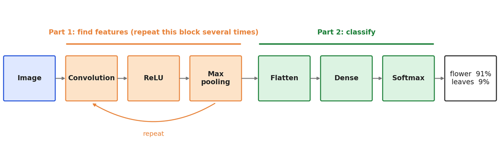

- **Convolution** finds patterns · **ReLU** keeps the matches · **Pooling** shrinks the maps
- **Flatten + Dense + Softmax**: the familiar network, giving class probabilities

Today: each component, then **one real image** through every layer **by hand**.

# Part 1. The Convolutional Layer

## A Color Image Is Three Grids of Numbers

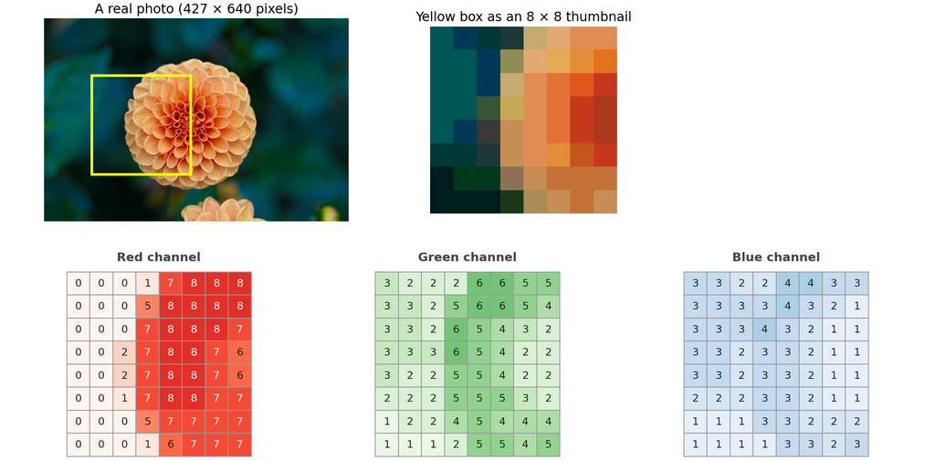

- A color image is **three** grids of numbers: how much **red**, **green**, and **blue** in each pixel. This one is 8 × 8 × 3.
- Real photos are big, so for hand work we take the yellow box and shrink it: each thumbnail pixel is the average of a 26 × 26 block.
- Real values go from 0 to 255; we round them to **0 to 9**. Left: dark teal leaves (low red). Right: orange petals (high red).

## The Convolutional Layer: A Filter With Three Layers

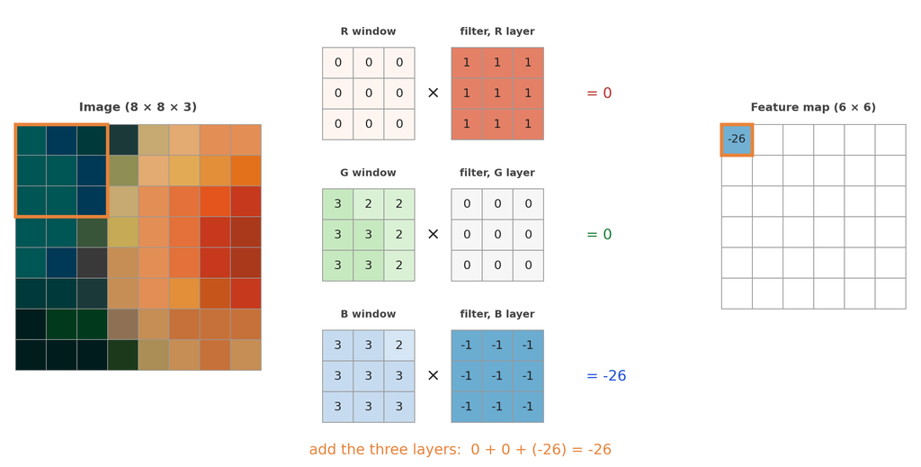

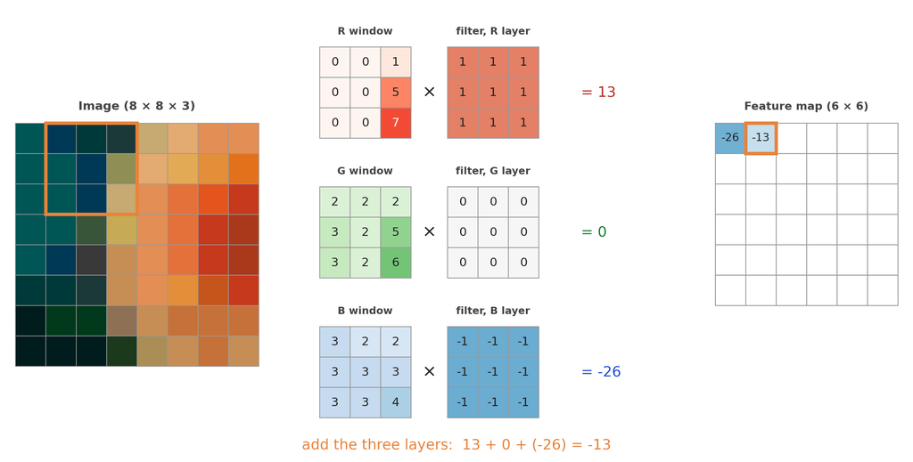

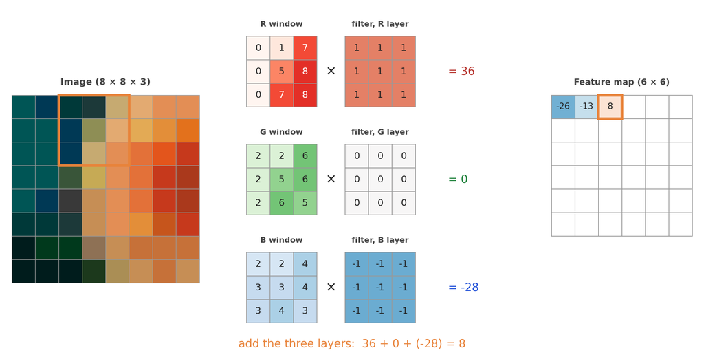

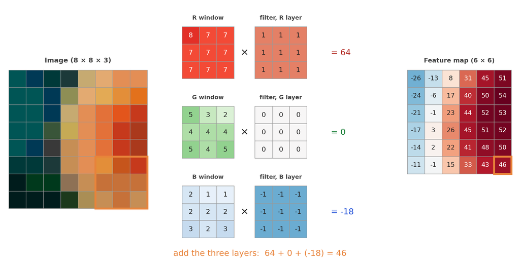

- On a color image the filter is **3 × 3 × 3**: one 3 × 3 layer per color. Multiply all 27 pairs and add: still **one number**.
- This filter is an **orange detector**: +1 on red, 0 on green, −1 on blue. It is large where there is much more red than blue.
- An 8 × 8 image and a 3 × 3 filter give a 6 × 6 **feature map**: $8 - 3 + 1 = 6$.

## What a Filter Finds

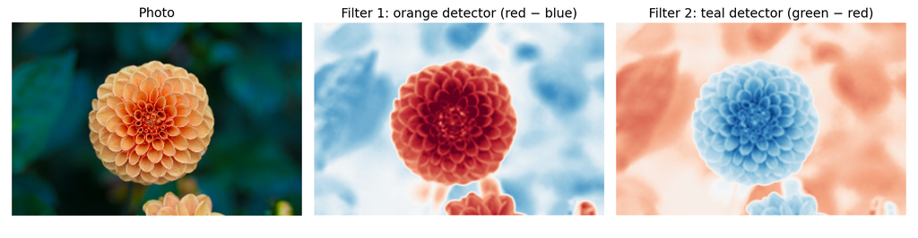

Nobody chooses the filter values. They are **weights**, learned in training like any other weights.

# Part 2. ReLU

## ReLU: Keep the Matches, Drop the Rest

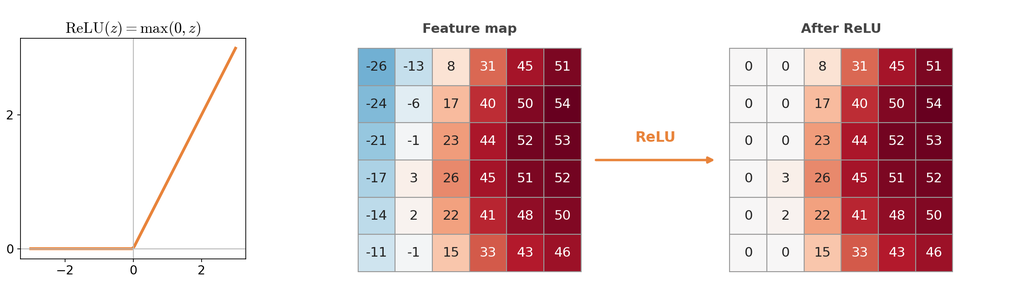

- ReLU is applied to **every number** in every feature map, one at a time. It has **no parameters**.
- Positive = “pattern found here”: **kept**. Negative = “pattern not here”: **set to 0**.
- Without it, stacked conv layers would collapse into one big linear filter. ReLU makes depth useful, and its slope of 1 keeps gradients from vanishing.

## ReLU on the Whole Photo

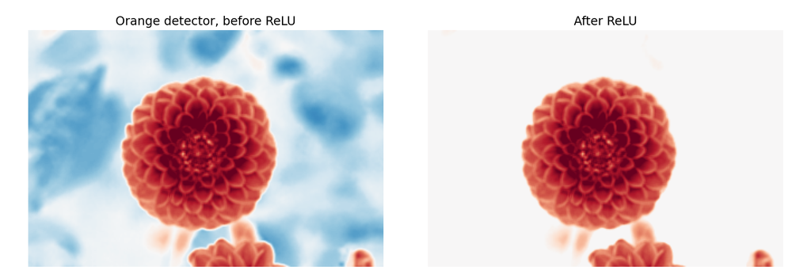

- ReLU keeps the red (orange petals found) and turns all the blue (no petals here) to 0.

# Part 3. Pooling

## Max Pooling: Shrink the Map, Keep the Strongest Signal

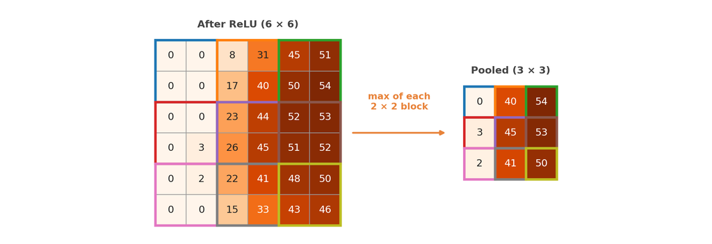

- Split each map into 2 × 2 blocks and keep the **largest** number. Height and width are cut in half.
- **Why**: fewer numbers for later layers; a feature that moves a pixel or two gives (almost) the same result; and the next filters see a **larger area** of the original image.
- **No parameters**, and it works on each feature map separately (the number of maps stays the same).

## Max Pooling on the Whole Photo

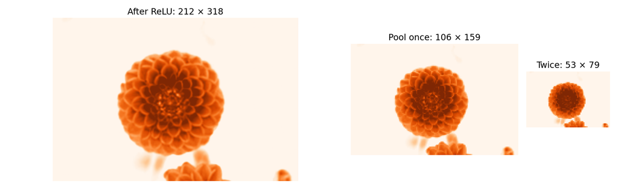

- Each pooling halves the height and width, yet the flower is still easy to see.

## Stacking the Block: Smaller Maps, More of Them

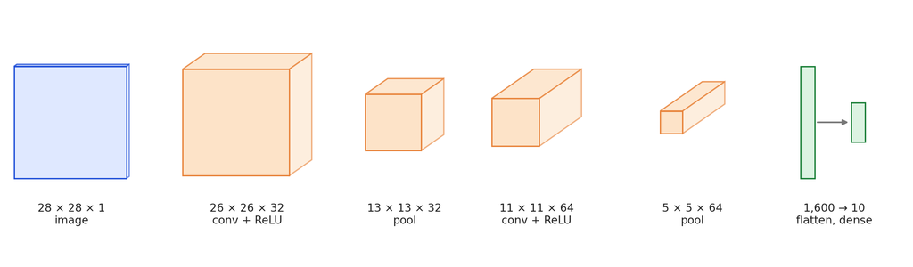

- Each conv + ReLU + pool block makes the maps **smaller** (pooling) but **more numerous** (more filters).
- Layer 1 filters see 3 × 3 pixels: edges. Later filters read earlier maps, so they see **larger areas** and find **combinations**: corners, textures, petals, eyes, wheels.

Early layers: simple, local patterns. Deep layers: complex patterns covering much of the image.

# Part 4. Flatten, Dense, Softmax

## From Feature Maps to Class Probabilities

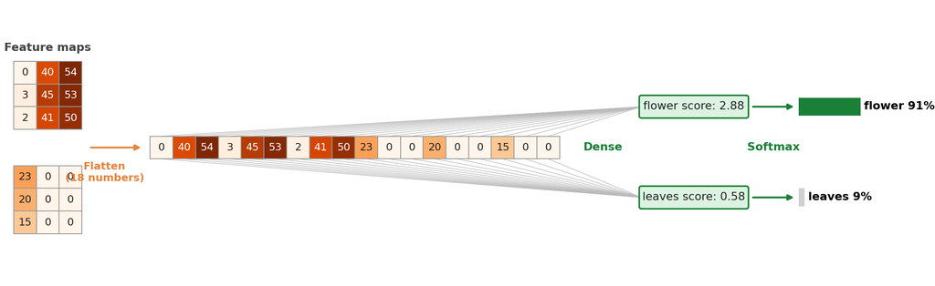

- **Flatten**: line up all the numbers from all the maps into one long list.
- **Dense layer**: each class gets a **score**, a weighted sum of every number in the list (the weights are learned).
- **Softmax**: turns the scores into **probabilities** that add up to 100%. The biggest one is the prediction.

This is the neural network we already know. The only difference: it reads the **features the filters found**, not raw pixels.

# Part 5. One Image Through the Network, by Hand

## The Network and the Image

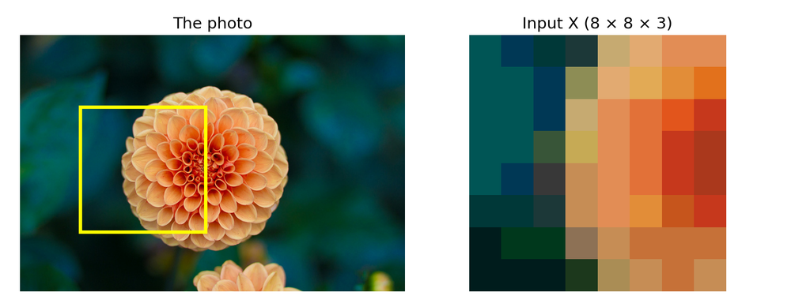

| Step | Layer | Output shape | Parameters |
| --- | --- | --- | --- |
| 1 | Convolution: 2 filters, 3 × 3 × 3 (orange detector, teal detector), bias 0 | 6 × 6 × 2 | 56 |
| 2 | ReLU | 6 × 6 × 2 | 0 |
| 3 | Max pooling 2 × 2 | 3 × 3 × 2 | 0 |
| 4 | Flatten | 18 | 0 |
| 5 | Dense: 2 classes (flower, leaves) | 2 | 38 |
| 6 | Softmax | 2 | 0 |
|  | **Total** |  | **94** |

## Step 1. Convolution: Two Filters, Two Feature Maps

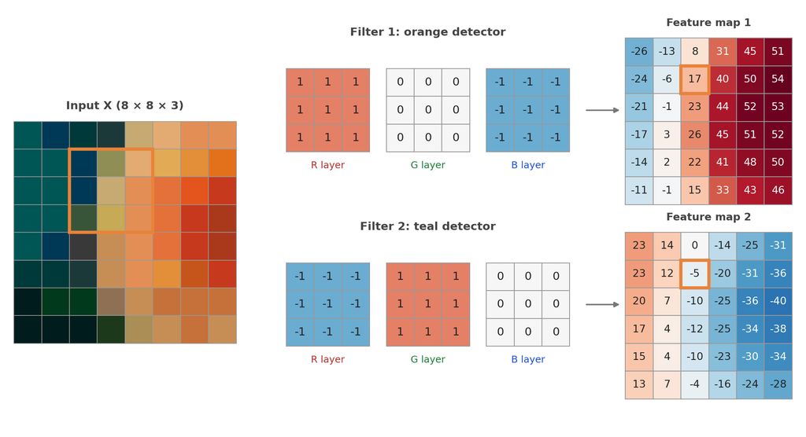

- Window in the orange box (row 2, column 3). **Filter 1** = (sum of red) − (sum of blue) $= 45 - 28 = 17$.

- **Filter 2** = (sum of green) − (sum of red) $= 40 - 45 = -5$.

- Slide to all 36 positions. Map 1 is large on the right (**orange petals**); map 2 is large on the left (**teal leaves**).

## Step 2. ReLU

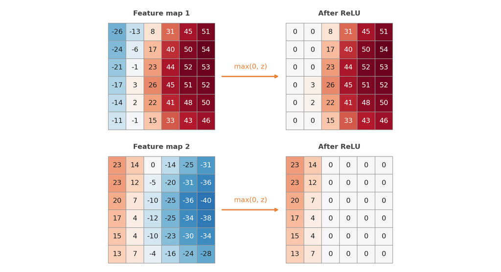

- Every negative number becomes 0; positives stay the same.

- Map 1 loses 10 numbers and map 2 loses 23: those windows showed the **opposite** of the filter’s pattern.

## Step 3. Max Pooling

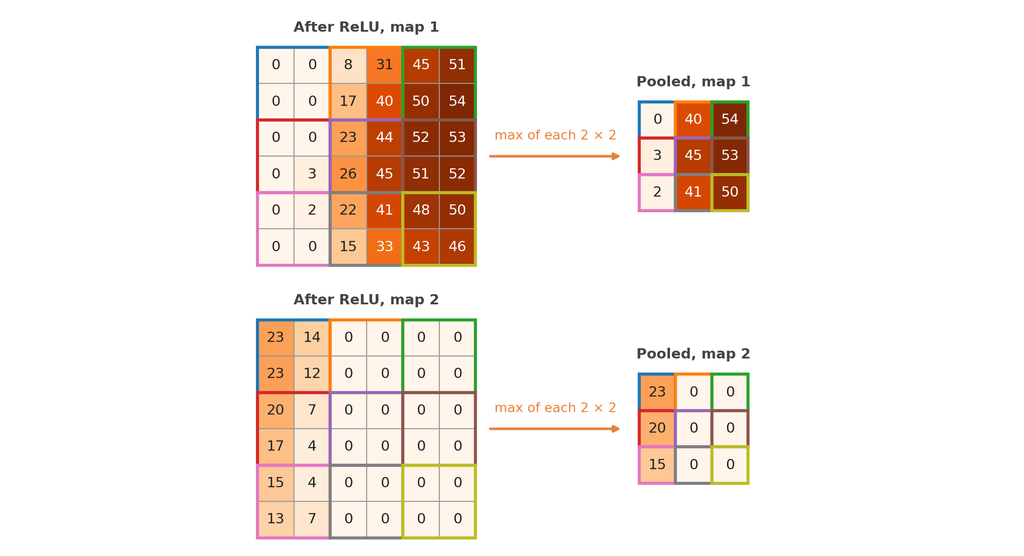

- Top-left block of map 1: $\max(0, 0, 0, 0) = 0$. Each 6 × 6 map becomes 3 × 3.

## Step 4. Flatten

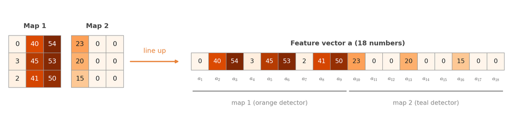

- Read each map row by row, map 1 then map 2: $\mathbf{a} = (0, 40, 54, 3, 45, 53, 2, 41, 50, 23, 0, 0, 20, 0, 0, 15, 0, 0)$.

- These 18 numbers describe the image: **how much orange and how much teal, in each of 9 regions**.

## Step 5. Dense Layer: Two Scores

|  | $a_1, \dots, a_9$ (map 1: orange) | $a_{10}, \dots, a_{18}$ (map 2: teal) | bias |
| --- | --- | --- | --- |
| **a** | 0, 40, 54, 3, 45, 53, 2, 41, 50 | 23, 0, 0, 20, 0, 0, 15, 0, 0 |  |
| weights, flower | 0.01 each | 0 each | 0 |
| weights, leaves | 0 each | 0.01 each | 0 |

- $z_{\text{flower}} = 0.01(0 + 40 + 54 + 3 + 45 + 53 + 2 + 41 + 50) = 0.01(288) = 2.88$

- $z_{\text{leaves}} = 0.01(23 + 0 + 0 + 20 + 0 + 0 + 15 + 0 + 0) = 0.01(58) = 0.58$

- Each score is **one inner product** of a weight row with $\mathbf{a}$ (zero weights left out).

## Step 6. Softmax: Probabilities

$$p_{\text{flower}} = \frac{e^{2.88}}{e^{2.88} + e^{0.58}}
= \frac{17.81}{17.81 + 1.79} = 0.909
\qquad
p_{\text{leaves}} = \frac{1.79}{17.81 + 1.79} = 0.091$$

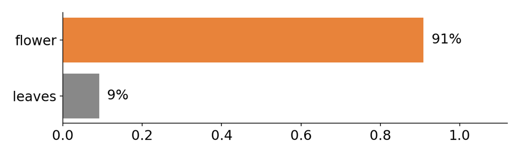

Prediction: **flower** with probability 91%. From 8 × 8 × 3 = 192 numbers to 2 probabilities, using only inner products, $\max(0, z)$, $\max$ of blocks, and softmax.

## The Whole Trip on One Slide

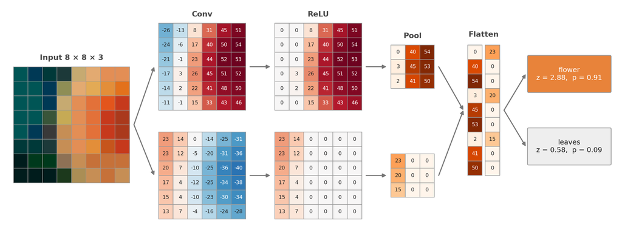

- Parameters learned in training: 2 filters (2 × 27 = 54 weights + 2 biases) and the dense layer (36 weights + 2 biases): **94** in total.

## Your Turn

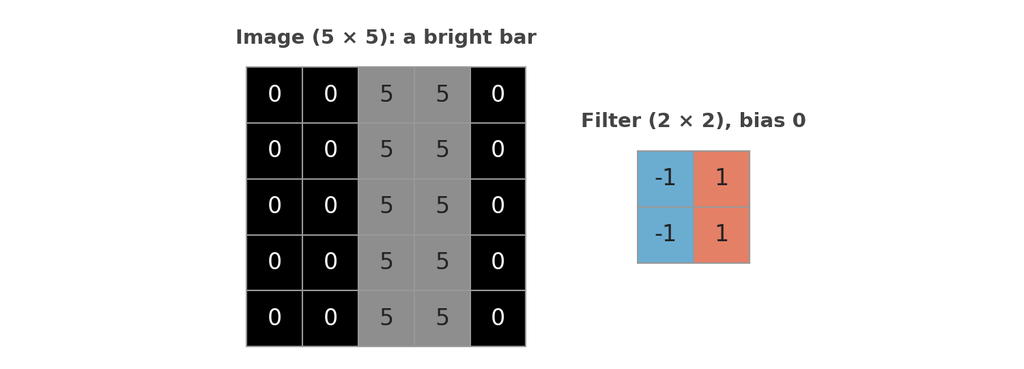

1. What is the size of the feature map? Compute it.
2. Apply ReLU. Which edge of the bar survives, and why?
3. Apply 2 × 2 max pooling.
4. How many parameters does this layer have if it uses 8 such filters on a color image?

## Your Turn: Answers

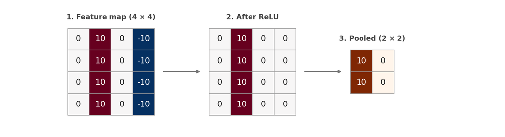

1. $5 - 2 + 1 = 4$, so 4 × 4. Each output is (right column) − (left column) of the window.

2. Only the **left** edge (dark → bright, value 10) survives; the right edge (bright → dark) is negative and becomes 0.

3. $\max$ of each 2 × 2 block, as shown.

4. Each filter is 2 × 2 × 3 with one bias: $(2 \cdot 2 \cdot 3 + 1)\cdot 8 = 104$.

# Part 6. A Real-Size CNN

## A CNN for 28 × 28 Handwritten Digits

| Layer | Output shape | Parameters |
| --- | --- | --- |
| Input | 28 × 28 × 1 | 0 |
| Conv, 32 filters 3 × 3, ReLU | 26 × 26 × 32 | 320 |
| Max pool 2 × 2 | 13 × 13 × 32 | 0 |
| Conv, 64 filters 3 × 3, ReLU | 11 × 11 × 64 | 18,496 |
| Max pool 2 × 2 | 5 × 5 × 64 | 0 |
| Flatten | 1,600 | 0 |
| Dense, 10 classes, softmax | 10 | 16,010 |
| **Total** |  | **34,826** |

- Same components as our hand calculation, just more filters and one more block.

- Second conv layer: each filter is 3 × 3 × **32**, because it reads all 32 maps of layer 1: $(3\cdot3\cdot32+1)\cdot64 =$ 18,496.

- In Keras: `Conv2D(32, 3, activation="relu")`, `MaxPooling2D(2)`, `Conv2D(64, 3, activation="relu")`, `MaxPooling2D(2)`, `Flatten()`, `Dense(10, activation="softmax")`.

## Training: Nothing New

- **Learned**: the filter weights and biases of every conv layer, and the weights and biases of the dense layer.
- **Not learned**: ReLU, pooling, and flatten have no parameters.
- **How**: exactly as before. Cross-entropy loss, gradients by backpropagation, gradient descent (Adam).
- The network discovers on its own which filters are useful: edge detectors appear in layer 1 without anyone designing them.

# Part 7. Famous CNNs

## Famous CNNs: The Same Two Parts

Every famous CNN has the shape of our Big Picture: **Part 1** (conv, ReLU, pooling, repeated) finds features; **Part 2** (flatten, dense, softmax) classifies them.

| Network | Year | Known for | Input | Classes | Parameters |
| --- | --- | --- | --- | --- | --- |
| **LeNet-5** | 1998 | reading handwritten digits on bank checks | 32 × 32 × 1 | 10 | about 60 thousand |
| **AlexNet** | 2012 | won ImageNet by a wide margin; started the deep learning boom | 227 × 227 × 3 | 1,000 | about 60 million |
| **VGG-16** | 2014 | very simple design: only 3 × 3 filters, stacked deep | 224 × 224 × 3 | 1,000 | about 138 million |
| **ResNet-50** | 2015 | “skip connections” make very deep networks trainable | 224 × 224 × 3 | 1,000 | about 26 million |

Over time Part 1 got **deeper** (more conv layers find richer features), while Part 2 stayed small or even shrank to a single dense layer.

## LeNet-5 (1998)

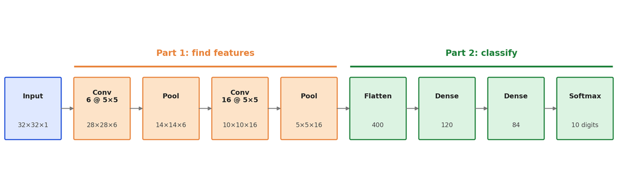

- Yann LeCun’s network for reading **handwritten digits**, used by banks to read checks in the 1990s.
- **Part 1**: two conv + pool blocks, 5 × 5 filters. **Part 2**: three dense layers, ending in 10 digit probabilities.
- Almost exactly the network from our “28 × 28 handwritten digits” slide: small, about **60 thousand** parameters.

## AlexNet (2012)

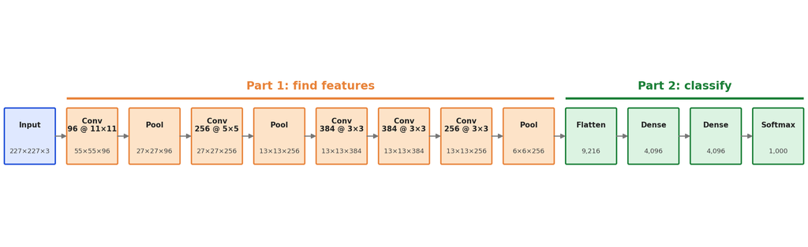

- Won the **ImageNet** challenge in 2012 (1.2 million color photos, 1,000 classes) with far fewer errors than any other method. This started the deep learning boom.
- **Part 1**: five conv layers (the first one with big 11 × 11 filters) and three pools. **Part 2**: two big dense layers + softmax.
- New tricks that are now standard: **ReLU**, training on **GPUs**, and dropout. About **60 million** parameters.

## VGG-16 (2014)

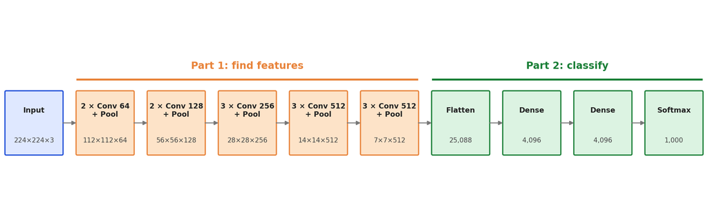

- A very regular design: **only 3 × 3 filters**, in five blocks; each block ends with a 2 × 2 max pool that halves the size.

- 13 conv layers + 3 dense layers = **16** layers with weights. About **138 million** parameters.

- Surprise: about **124 million** of them are in **Part 2** (the first dense layer alone reads 25,088 numbers).

## ResNet-50 (2015)

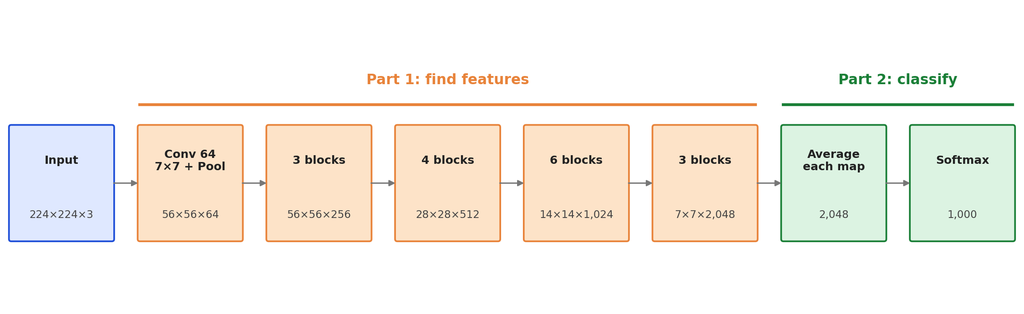

- **50 layers deep.** Each “block” is 3 conv layers plus a **skip connection** that adds the block’s input to its output, which makes very deep networks trainable.
- **Part 2 is tiny**: instead of flattening, average each of the 2,048 maps into one number, then one dense layer + softmax.
- Fewer parameters than VGG-16 (about **26 million**) but more accurate. Variants of ResNet are still widely used today.

## Summary

| Component | What it does | Parameters |
| --- | --- | --- |
| **Convolution** | a small filter slides; each output is an inner product with one window | $(f \cdot f \cdot c_{\text{in}} + 1)\cdot k$ |
| **ReLU** | $\max(0, z)$: keep where the pattern was found | 0 |
| **Max pooling** | keep the largest value in each 2 × 2 block; halves the size | 0 |
| **Flatten** | line up all maps into one vector | 0 |
| **Dense** | $W\mathbf{a} + \mathbf{b}$: one inner product per class | $(m + 1)\cdot K$ |
| **Softmax** | scores → probabilities that add to 1 | 0 |

Convolution blocks **find features**; the dense layer **classifies** them. Everything is inner products plus two simple $\max$ operations.

# Part 8. Practice Problems

## Practice Problems

Six problems, all done **by hand** (whole numbers, plus a calculator for one softmax). Each problem is followed by a step-by-step solution.

| Problem | Skill |
| --- | --- |
| 1 | One color filter on a pixel: which filter fires? |
| 2 | Convolution on a color image, with a bias, then ReLU |
| 3 | A full trip on a grayscale image: convolution, ReLU, pooling, flatten, dense, softmax |
| 4 | The same full trip on a color image (a 2 × 2 × 3 filter) |
| 5 | Output shapes and parameter counts |
| 6 | Why pooling helps when the object moves |

## Practice 1. Which Filter Fires?

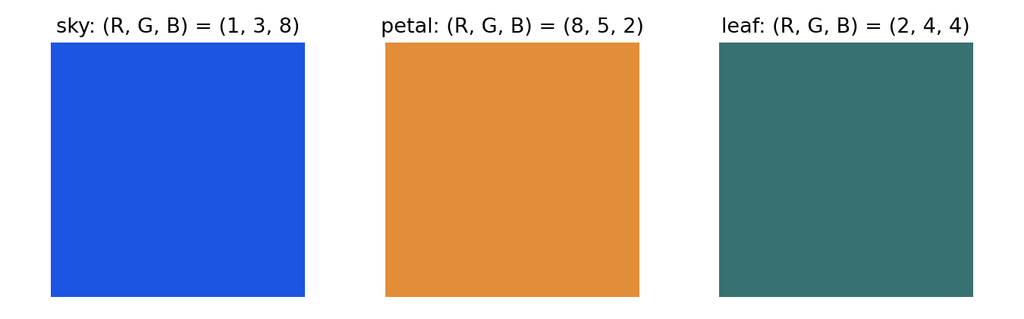

Each patch is a 3 × 3 window where **every pixel has the same color**. Use our two filters from class: **filter 1** (orange detector) has +1 on every red weight, −1 on every blue weight, 0 on green; **filter 2** (teal detector) has +1 on green, −1 on red, 0 on blue. Biases are 0.

1. Compute the output of filter 1 and filter 2 on each patch. (Hint: 9 equal pixels, so the output is $9 \times$ one pixel’s result.)
2. Apply ReLU. Which patches does each filter “find”?
3. Write down a 3 × 3 × 3 **blue-sky detector** that is large on the sky and 0 after ReLU on the petal. What is its output on the sky?

## Practice 1: Solution (a) — Filter Outputs

**Why the shortcut works.** A filter output is the sum of (weight × pixel value) over all 27 positions of the 3 × 3 × 3 window. When all 9 pixels have the same color $(R, G, B)$:

$$\text{filter 1} = \underbrace{9 \cdot (+1) \cdot R}_{\text{red layer}} + \underbrace{9 \cdot 0 \cdot G}_{\text{green layer}} + \underbrace{9 \cdot (-1) \cdot B}_{\text{blue layer}} = 9(R - B), \qquad \text{filter 2} = 9 \cdot (-1) \cdot R + 9 \cdot (+1) \cdot G + 9 \cdot 0 \cdot B = 9(G - R)$$

| Patch | Filter 1 (orange): $9R - 9B$ | Filter 2 (teal): $-9R + 9G$ |
| --- | --- | --- |
| **sky** $(1, 3, 8)$ | $9(1) + 0 - 9(8) = 9 - 72 = -63$ | $-9(1) + 9(3) + 0 = -9 + 27 = 18$ |
| **petal** $(8, 5, 2)$ | $9(8) + 0 - 9(2) = 72 - 18 = 54$ | $-9(8) + 9(5) + 0 = -72 + 45 = -27$ |
| **leaf** $(2, 4, 4)$ | $9(2) + 0 - 9(4) = 18 - 36 = -18$ | $-9(2) + 9(4) + 0 = -18 + 36 = 18$ |

- Example, sky with filter 1: the 9 red weights each multiply a red value of 1, giving $9 \times 1 = 9$; the 9 blue weights each multiply $-1 \times 8$, giving $-72$; green adds 0. Total $9 + 0 - 72 = -63$.
- A **positive** output means the window has more of the filter’s “+” color than its “−” color.

## Practice 1: Solution (b, c) — ReLU and a New Filter

| Patch | Filter 1 after ReLU | Filter 2 after ReLU | Blue detector $9B - 9R$, then ReLU |
| --- | --- | --- | --- |
| **sky** | $\max(0, -63) = 0$ | $\max(0, 18) = 18$ | $9(8) - 9(1) = 63 \to 63$ |
| **petal** | $\max(0, 54) = 54$ | $\max(0, -27) = 0$ | $9(2) - 9(8) = -54 \to 0$ |
| **leaf** | $\max(0, -18) = 0$ | $\max(0, 18) = 18$ | $9(4) - 9(2) = 18 \to 18$ |

- **b.** Filter 1 survives ReLU only on the **petal** (54): the only patch with more red than blue. Filter 2 survives on the **sky** (18) and the **leaf** (18): both have more green than red. A filter does not “know” what a leaf is; it responds to **its color pattern wherever it occurs**, so the network needs several filters together to tell sky from leaf.
- **c.** Put **+1 on every blue weight**, **−1 on every red weight**, 0 on green (bias 0). Its output is $9(B - R)$: sky $9(8 - 1) = 63$ (large, found); petal $9(2 - 8) = -54 \to 0$ (not found). Other answers work too, e.g. blue − green gives sky $9(8 - 3) = 45$ and petal $9(2 - 5) = -27 \to 0$.

## Practice 2. Convolution on a Color Image

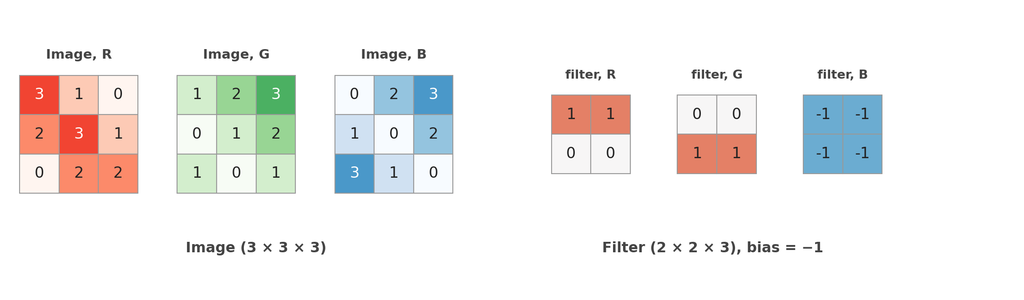

1. What is the size of the feature map?
2. Compute every number of the feature map. (For each window: R part + G part + B part + bias.)
3. Apply ReLU.
4. How many parameters does this layer have? How many if it used 10 such filters?

## Practice 2: Solution (a) — Size and the Recipe

- **a.** Output size $= n - f + 1 = 3 - 2 + 1 = 2$, so the feature map is **2 × 2**. A 2 × 2 window fits in **2** positions across and **2** down, so there are 4 windows.
- The depth of the filter (3) matches the depth of the image (3), so each window position gives **one number**, not three.
- Read the filter one layer at a time, so each window needs only short sums:

| Filter layer | Weights | What it computes on a window |
| --- | --- | --- |
| R | top row +1, bottom row 0 | **R part** = sum of the window’s **top row of red** |
| G | top row 0, bottom row +1 | **G part** = sum of the window’s **bottom row of green** |
| B | all −1 | **B part** = −(sum of **all four blue** values) |

$$z = \text{R part} + \text{G part} + \text{B part} + \text{bias}, \qquad \text{bias} = -1$$